# Simulating Gerrymandering

*What good is a democracy if the people don’t have power?*

# What is Gerrymandering?

If you haven’t heard of it yet, it’s the practice of (strategically) drawing district lines to give a party an advantage in elections. Ideally, the party that gets the most votes (overall), should also get the majority of seats. However, with gerrymandering, this is not always the case. For example, in the 2016 US presidential election, the Democrats got more votes overall, but the Republicans won the presidency. While this is not because of gerrymandering, it shows how majority of votes does not always mean that that party will win.

Usually, parties will draw district lines to pack as many of the opposing party’s voters into as few districts as possible, while spreading their own voters out over many districts. This way, they can win more districts with fewer votes. In other words, they can have the majority of the seat, but not the majority of the votes (which sure seems unfair).

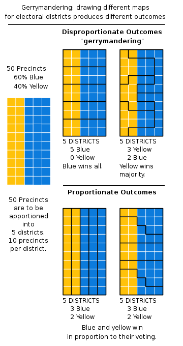

[Wikipedia](https://en.wikipedia.org/wiki/Gerrymandering)

# Simulating Gerrymandering

What does it even mean to simulate gerrymandering? We can create a simple model of a state (let’s say CA) with a certain number of blocks (census blocks, which are smaller than the districts), and then draw district lines. We can then see how many seats each party wins when the districts are drawn in different ways. Ideally, we would want to the entire sample space of possible district lines, but that would be computationally infeasible. Instead, we can use a simple MCMC simulation to draw a large number of district lines and see how many seats each party wins in each case. From those results, we can see where the current district lines fall in the distribution of possible district lines. If it is an outlier, then we can say that it is likely gerrymandered.

# Making Our Own State

Let’s start by making our own state. We will make a simple state with 100 blocks. We will randomly assign each block to a party (either party A or party B) with probability 0.55 (so that part A should have a slight majority). To visualize the state, we will use a graph, where the nodes are the blocks and the edges are the neighbors (blocks that share a border). The color of the node will represent the party that the block is assigned to (blue for A and red for B).

```python
import networkx as nx
import matplotlib.pyplot as plt
import random
import numpy as np
```

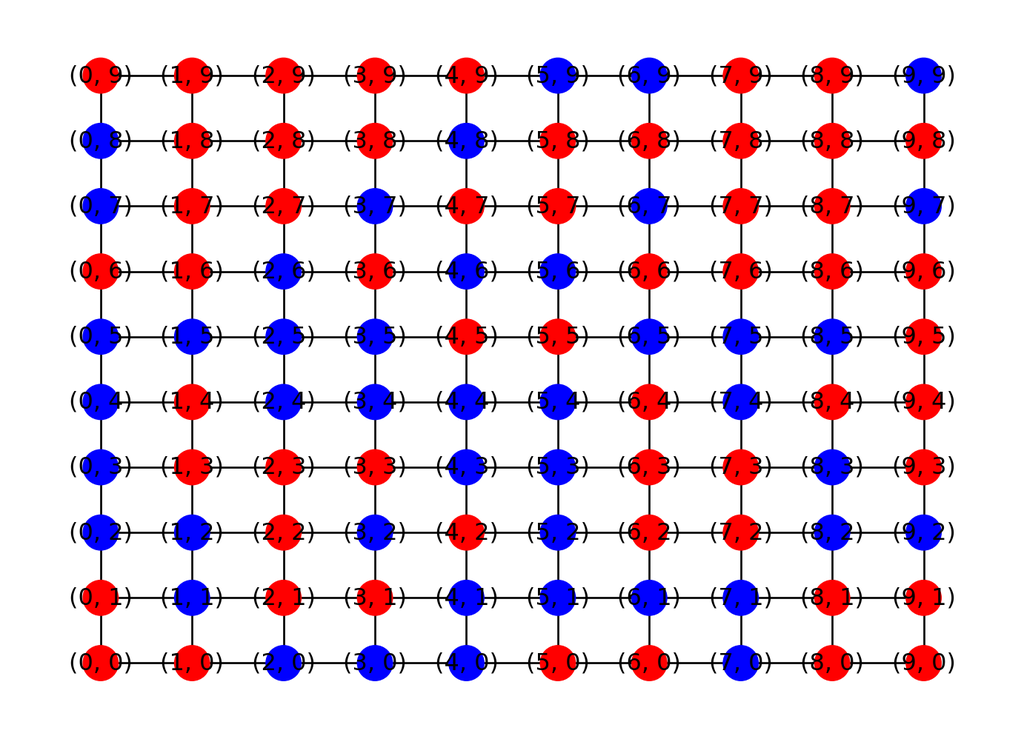

```python
random.seed(0)
G = nx.grid_2d_graph(10, 10)
for node in G.nodes:
    G.nodes[node]['party'] = 'A' if random.random() < 0.55 else 'B'
    G.nodes[node]['color'] = 'blue' if G.nodes[node]['party'] == 'A' else 'red'

plt.figure()
pos = {(i, j): (i, j) for i, j in G.nodes}
colors = [G.nodes[node]['color'] for node in G.nodes]
nx.draw(G, pos, node_color=colors, with_labels=True)
plt.show()
```

Of course, this is a extremely oversimplified model of a state. In reality, states have many more blocks and the blocks are not arranged in a grid. However, this simple model should still demonstrate the idea of how we can detect gerrymandering using MCMC.

# Drawing District Lines

Now that we have our state, we can draw district lines. We will draw 5 districts, where each district has 20 blocks. We will color the districts differently, so that we can see where the district lines are.

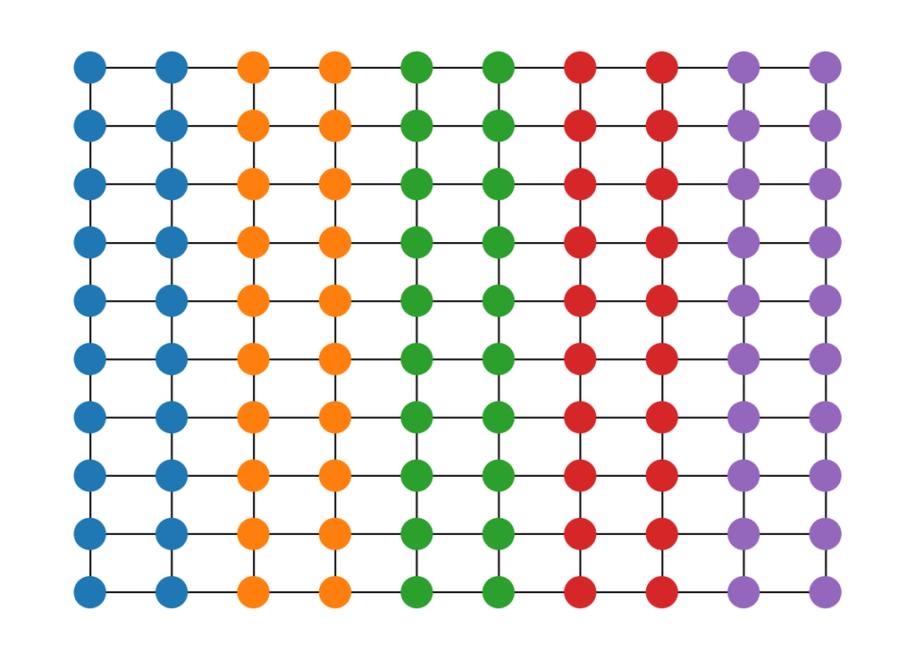

```python
nodes = list(G.nodes)

districts = []

# Create districts by iterating over nodes sequentially
for i in range(0, len(nodes), 20):  # Adjust the district size as needed
    district = nodes[i:i+20]
    districts.append(district)

# Assign a color to each district
for i, district in enumerate(districts):
    for node in district:
        G.nodes[node]['color'] = 'C' + str(i)

plt.figure()
pos = {(i, j): (i, j) for i, j in G.nodes}
colors = [G.nodes[node]['color'] for node in G.nodes]
nx.draw(G, pos, node_color=colors, with_labels=False)
plt.show()
```

# The Data

Before we can simulate gerrymandering, we need to get some data. We will use the census block data from the 2010 census. This data is available from the US Census Bureau. We will use the `census` package to get the data.